# Workshop analyzing intensive longitudinal data with n=1 and multilevel autoregressive models

Noémi Schuurman

July 2021 at EAM

In this practical you will practice with fitting multiple (Bayesian) single subject models for intensive longitudinal data, specifically AR(1) and AR(2) models, an AR(1) model with a covariate, a VAR(1) model and as a bonus, two models that account for measurement error. You will fit the models for the data of two participants to get an impression of individual differences in dynamics.

## Installing and loading packages

The analyses in this lab depend on two `R`-packages: [rjags](https://cran.r-project.org/web/packages/rjags/index.html), for fitting the Bayesian models; [coda](https://cran.r-project.org/web/packages/coda/index.html), for running summary stats and plots on the Bayesian analysis results. In order for these analyses to run on your computer, you will also need to download and install [JAGS](https://sourceforge.net/projects/mcmc-jags/), because rjags depends on this program.

```r
if (!require("rjags")) install.packages("rjags")
if (!require("coda")) install.packages("coda")


library(rjags)
library(coda)
```

## Loading the data

We will work with the two .Rds files for two female participants Jane and Mary (Names ficional, data courtesy of Schuurman, Houtveen and Hamaker, 2015). The data consists of daily diary measurements, for 91 days for Jane and 105 days for Mary. The data contains various measures on mood, positive and negative affect and symptoms surrounding the women’s periods. Load the data with function `readRDS()’:

```r
mydata_Jane= readRDS("data_Jane.Rds")

mydata_Mary= readRDS("data_Mary.Rds")
```

Note that the variable names in the files are in Dutch, but we will translate the relevant variables on the go when we use them.

We will start by looking at both women’s rating (scale 1-100 low-high) of their daily overall mood.

```r
###Extracting mood from Jane's dataset##
dat_Jane=as.matrix(mydata_Jane$scale)
colnames(dat_Jane) = c("mood")

###Extracting mood from Mary's dataset##
dat_Mary=data.frame(mydata_Mary$scale)
#dat_Mary=as.matrix(dat_Mary)
colnames(dat_Mary) = c("mood")
```

## Exploring the data

From now on the code we have prepared is code for Jane, but not for Mary. Try to adjust the code for Mary yourself.

We start by making a time series plot for the mood of both participants.

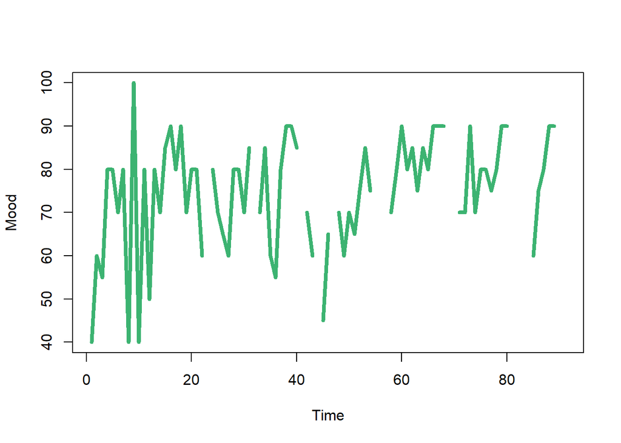

```r
###Visualizing the data of Jane: Time series plot##
ts.plot(dat_Jane,col="mediumseagreen",lwd=4, ylab= "Mood")
```

```r
###Visualizing the data of Mary: Time series plot
```

Now compare the means, variance and standard deviations. Who has a higher mood, Jane or Mary? Who varies the most on mood? Who has the most missing data points?

```r
###Exploring the data of Jane:
mean(dat_Jane, na.rm=TRUE)
```

```
## [1] 74.93421
```

```r
var(dat_Jane, na.rm=TRUE)
```

```
##          mood
## mood 173.6623
```

```r
sd(dat_Jane, na.rm=TRUE)
```

```
## [1] 13.1781
```

```r
sum(is.na(dat_Jane))
```

```
## [1] 15
```

```r
###Exploring the data of Mary:
```

## Basic AR models

Now we inspect the autocorrelations and partial autocorrelations for the data of each woman using the functions `acf()`, and `pacf()`.

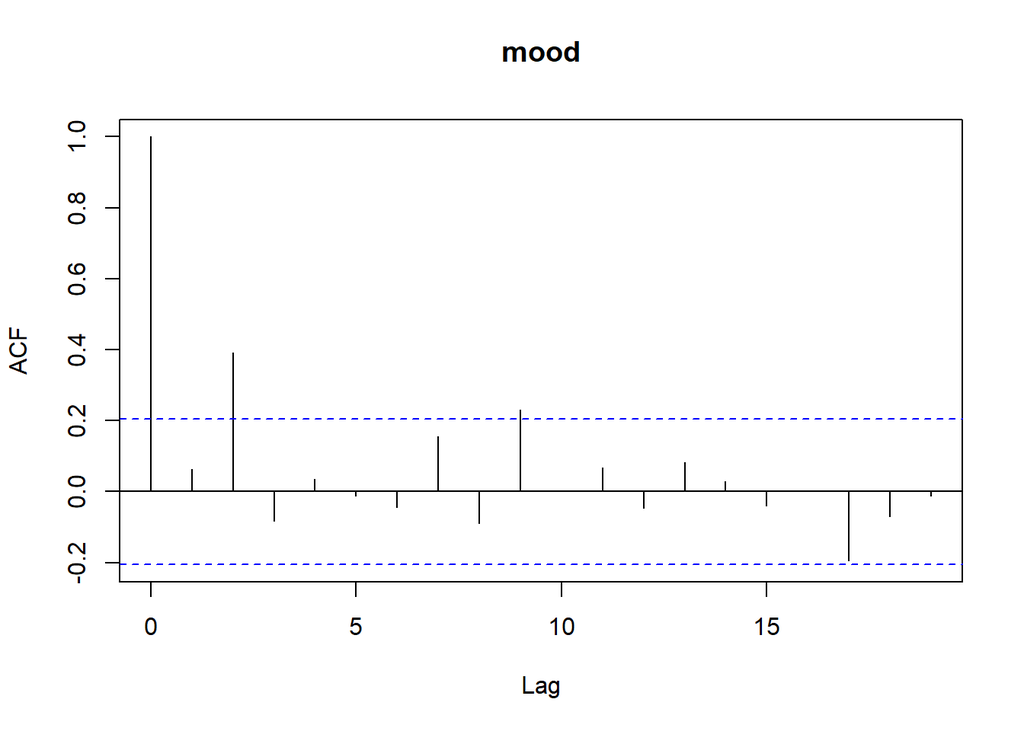

```r
### ACF and PACF Jane:
acf(dat_Jane,na.action=na.pass)
```

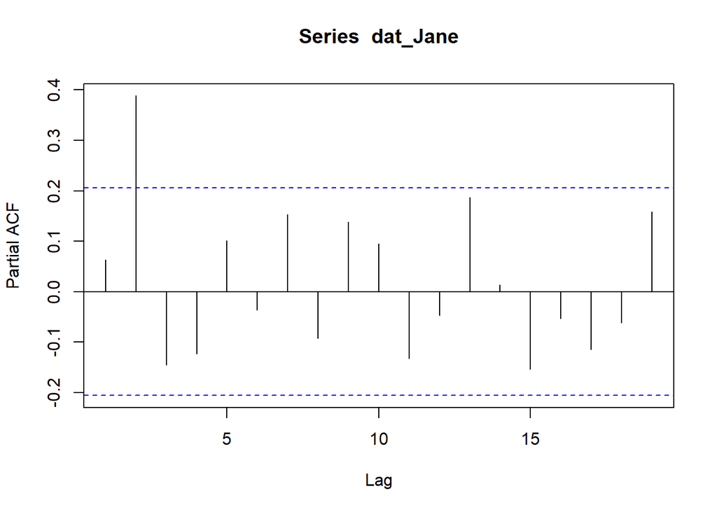

```r
pacf(dat_Jane,na.action=na.pass)
```

```r
### ACF and PACF Mary:
```

Based on the autocorrelations and partial autocorrelations for the different lags of the women’s data, what order of autoregressive model would you fit for each of them (how many lags would you like to include)?

### Simple AR(1) Model in R with lm()

The simplest way to fit a n=1 time series model is estimating it as a standard frequentist regression model, for example using the `lm()` function. For this we need to first create a lagged predictor variable. For now, we will use now only a lag-1 model.

```r
## A function to lag the data ##
lagmatrix <- function(x,max.lag) embed(c(rep(NA,max.lag), x), max.lag+1)

## Lag the data of Jane ##
y1L_Jane=lagmatrix(dat_Jane,1)[,2] #Make sure to change the name y1L_Jane to y1L_Mary for Mary's data

## Compare the original dat_Jane (first column) with the lagged y1L (second column) ##
cbind(dat_Jane,y1L_Jane)
```

```
##       mood y1L_Jane
##  [1,]   40       NA
##  [2,]   60       40
##  [3,]   55       60
##  [4,]   80       55
##  [5,]   80       80
##  [6,]   70       80
##  [7,]   80       70
##  [8,]   40       80
##  [9,]  100       40
## [10,]   40      100
## [11,]   80       40
## [12,]   50       80
## [13,]   80       50
## [14,]   70       80
```

[output cut: 77 more lines]

```r
# Do you see what has happened for our new variable y1L_Jane?

## Lag the data of Mary ##


## Estimating an AR(1) model using ordinary least squares (OLS) for Jane ##
#First, we estimate the AR1 model with the use of OLS estimation, a simple linear model:
ar1lm_Jane <- lm(dat_Jane~y1L_Jane)
summary(ar1lm_Jane)
```

```
##
## Call:
## lm(formula = dat_Jane ~ y1L_Jane)
##
## Residuals:
##     Min      1Q  Median      3Q     Max
## -38.021  -6.667   3.333   8.925  26.039
##
## Coefficients:
##             Estimate Std. Error t value Pr(>|t|)
## (Intercept) 71.25396    8.93122   7.978 3.52e-11 ***
## y1L_Jane     0.06767    0.11821   0.572    0.569
## ---
## Signif. codes:  0 '***' 0.001 '**' 0.01 '*' 0.05 '.' 0.1 ' ' 1
##
## Residual standard error: 12.66 on 64 degrees of freedom
##   (25 observations deleted due to missingness)
## Multiple R-squared:  0.005094,   Adjusted R-squared:  -0.01045
## F-statistic: 0.3277 on 1 and 64 DF,  p-value: 0.569
```

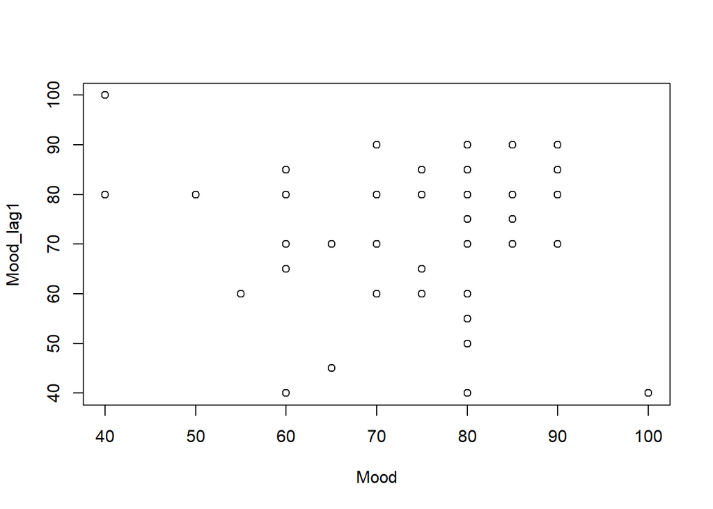

```r
# Interpret the results.Note the remark in the output on the (listwise) deletion of missing observations!


plot(cbind(dat_Jane,y1L_Jane),xlab ="Mood",ylab="Mood_lag1" ) # Visualize the autocorrelation.
```

```r
## Do the same for Mary ##


# Who has the strongest autoregressive effect? Note that for a stationary AR(1) model, the autoregressive coefficients are standardized because the variance of the outcome variable and predictor variable have to be equal for a stationary model.
```

### Simple AR Models in R with arima()

We can easily fit n=1 time series models with package `arima` which is native in R. Fit at least an order 1 (i.e., lag-1), and an order 2 (i.e., lag-2) autoregressive model for both women using package arima.

ARIMA uses a state space modeling framework which combines maximum likelihood estimation and the kalman filter by default. Use ?arima in R to learn more. It hence differs from the OLS approach above with ‘lm()’, for example because missing data is simply deleted in the OLS case. An important advantage of the arima (and also the Bayesian) approach over the lm approach in the previous exercise, is that we do not supplement the lagged variable as an exogenous variable (which we had to make ourselves). The lagging is taken care of by how we specify the model and estimate it (this wil be more obvious in the Bayesian exercise).

Interpret and compare the results for both women. Are the autoregression coefficients similar between the ARIMA and OLS estimation procedures?

What model do you prefer for Jane and for Mary? You can base this either on your interpretation of the model and the resulting coefficients, and/or on the AIC the arima function provides (smaller values indicating a better model).

```r
###AR(1) and AR(2) model fitted for Jane in arima##
ar1arima <- arima(dat_Jane, c(1,0,0))
ar1arima
```

```
##
## Call:
## arima(x = dat_Jane, order = c(1, 0, 0))
##
## Coefficients:
##          ar1  intercept
##       0.0752    74.8807
## s.e.  0.1321     1.6063
##
## sigma^2 estimated as 170.5:  log likelihood = -303.15,  aic = 612.29
```

```r
ar2arima <- arima(dat_Jane, c(2,0,0))
ar2arima
```

```
##
## Call:
## arima(x = dat_Jane, order = c(2, 0, 0))
##
## Coefficients:
##          ar1     ar2  intercept
##       0.0840  0.4070    74.7038
## s.e.  0.1053  0.1089     2.4736
##
## sigma^2 estimated as 141.8:  log likelihood = -297.22,  aic = 602.43
```

```r
###AR(1) and AR(2) model fitted for Mary in arima##
```

### Bayesian n=1 AR(1) Analysis

Next, we will fit the AR(1) model in a Bayesian way, with the Bayesian software JAGS. We will use R from JAGS with package Rjags.

In the file ‘AR1model.txt’ you will find the JAGS code for the model, which we will supply to jags for the analysis. It is also presented here below. Take a look at the model specification, including the priors that were specified. Do you understand what is being specified where?

Note: The priors specified are intended to be uninformative. Some notes on reading the code:

- The ordering of the lines in JAGS codes does not matter (hence we can specify the function for y[t] before the function of muy[t] in the code below).
- Normal distributions in Jags are specified with a mean and precision (1/variance), rather than with a mean and variance. So, X ~ Normal(mean, variance) in JAGS would be translated as X~dnorm(mean,1/variance).
- The function dunif(a,b) indicates a uniform distribution with minimum value a and maximum value b.

```r
"
model{


#####model######
    for (t in 2:nt) ###model for timepoint 2 onwards
    {
        y[t]~dnorm(muy[t],Ipre)  ###Ipre is innovation precision
        muy[t]<- mu + phi*z[t-1] ## mu is mean, phi is autoregressive parameters
        z[t] <- y[t]-mu     ##We do this step to center our observed variable in the model, so in the previous line we estimate a mean mu rather than an intercept there.

    }

####timepoint 1#######

    z[1] <- y[1]-mu  ###model for time point one.



####priors###########

    Ipre <- inverse(Ivar) ## innovation precision
    Ivar ~dunif(0,300)   ##innovation variance

    phi~dunif(-1,1) ##autoregression coefficient
    mu~dnorm(50,.001) ##mean



}
"
```

We will fit the model in JAGS via package rjags with three chains. For each chain, initial values for each parameter can be specified in lists as follows:

```r
#specify initial values for each chain
ins = list(list( phi=.6, Ivar = 100,  mu=50),
           list( phi=.3, Ivar = 60,  mu=60),
           list( phi=-.2, Ivar = 80, mu = 70))  ###initial values for three chains.
###Here, the initial values for Ivar and mu are very roughly based on what we know about the measurement scale of our variable.

#specify the number of time points in the data (needed as data for the jags model, such that jags knows what 'nt' is in the JAGS code).
nt=length(dat_Jane)
```

It is also possible to not specify any starting values, in which case they will be generated automatically by jags - they will be sampled from the specified priors.

Next, we specify the model file, data to be used with the model file (for Jane), initial values, and the number of chains, for compiling the model in JAGS and rjags. We use a burn-in of 2000 samples per chain. We take 2000 samples on which we will base our results.

```r
###Specify modelfile, data, initial values, and number of chains for compiling the rjags model:
jags_AR1 <- jags.model('AR1model.txt',
                   data = list('nt' = nt,
                               'y' = as.numeric(dat_Jane)

                   ),
                   inits=ins,
                   n.chains = 3) ###compile and initialize jags AR model
update(jags_AR1, 2000) ####burn-in samples/iterations, to be discarded

samps_AR1=coda.samples(jags_AR1,
                   c('phi','mu','Ivar'),
                   2000) ### take the samples/iterations we will use for the                               results,we store the samples for parameters phi, mu and Ivar, so we can get results for these.
```

The model has been fitted. Before showing the results, we’ll do some convergence checks, specifically, we check the density plots, trace plots, and the gelman-rubin statistics (plots and summary stats):

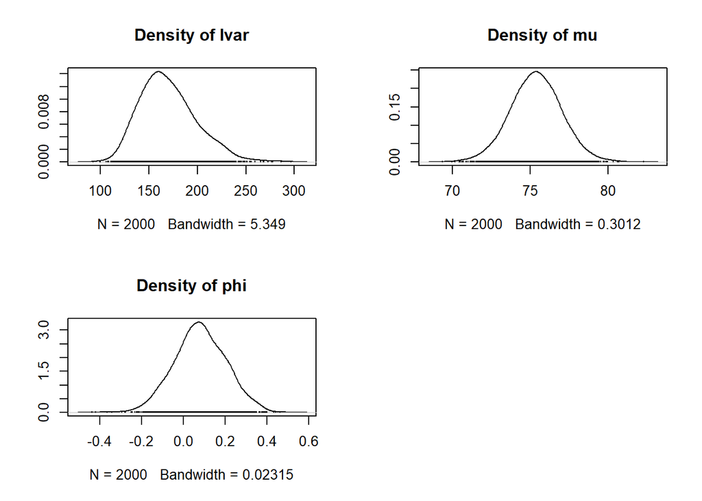

```r
plot(samps_AR1,trace=FALSE) ##plot the marginal posterior densities, should look smooth, unimodal, usually normal
```

```r
gelman.diag(samps_AR1) ###plot gelman rubin stats Should be 1 or very very near 1 (smaller than 1.05)
```

```
## Potential scale reduction factors:
##
##      Point est. Upper C.I.
## Ivar       1.01       1.02
## mu         1.00       1.00
## phi        1.00       1.00
##
## Multivariate psrf
##
## 1
```

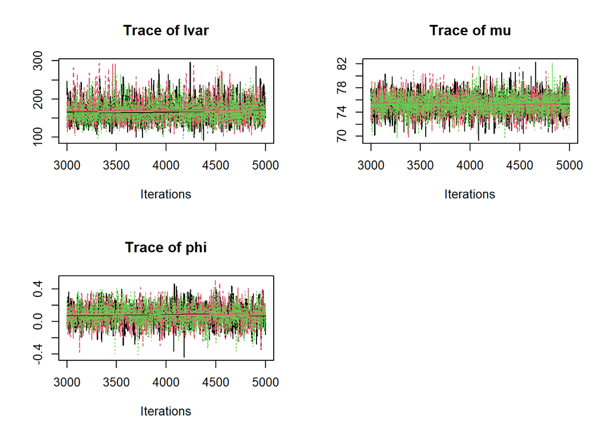

```r
plot(samps_AR1,density=FALSE) ##traceplots should look like a pile of different colored hairy catterpillars
```

The density plots are nice and smooth, trace plots look like fat catterpillars, gelman-rubin statistics are good. Convergence seems in order. The resulting parameter estimates:

```r
summary(samps_AR1) ##results parameter estimates
```

```
##
## Iterations = 3001:5000
## Thinning interval = 1
## Number of chains = 3
## Sample size per chain = 2000
##
## 1. Empirical mean and standard deviation for each variable,
##    plus standard error of the mean:
##
##           Mean      SD Naive SE Time-series SE
## Ivar 170.12644 29.3577 0.379006       0.616991
## mu    75.37444  1.6544 0.021359       0.025376
## phi    0.07989  0.1246 0.001609       0.002883
##
## 2. Quantiles for each variable:
##
##          2.5%        25%       50%     75%   97.5%
## Ivar 122.7031 149.040192 166.66726 187.559 234.500
## mu    72.0948  74.288909  75.37528  76.458  78.665
## phi   -0.1648  -0.001759   0.07829   0.165   0.326
```

Interpret the results. In the summary results you find the mean estimate for each parameter and the posterior standard deviation (similar in use to a frequentist standard error), and the quantiles for the posterior distribution. The mean or median estimate are often used as the point estimate for a parameter. The first and last quantile in the results can be used to form the lower and upper bound of a 95% credible interval for each parameter.

Additional exercises:

- Are the results similar to those from arima and OLS procedure?
- Rerun the model with a larger number of burnin and iterations. Do the results change (if the model has converged, the changes should be very small)?
- Change the priors and starting values. Does it affect the results? Now fit the Bayesian AR(1) model for Mary.

### Bayesian n=1 AR2 Analysis

Next, fit the AR2 model for Jane and Mary. You can try to adapt the AR(1) model code yourself, or use the pre-specified code in the file “AR2model.txt”. If the latter, be sure to inspect this code and see if you get the alterations compared to the AR(1) model.

```r
ins = list(list( phi=.6,phi2=.2, Ivar = 100,  mu=50),
           list( phi=.3,phi2=-.5, Ivar = 60,  mu=60),
           list( phi=-.2,phi2=0, Ivar = 80, mu = 70))

jags_AR2 <- jags.model('AR2model.txt',
                   data = list('nt' = nt,
                               'y' = as.numeric(dat_Jane)

                   ),
                   inits=ins,
                   n.chains = 3)
```

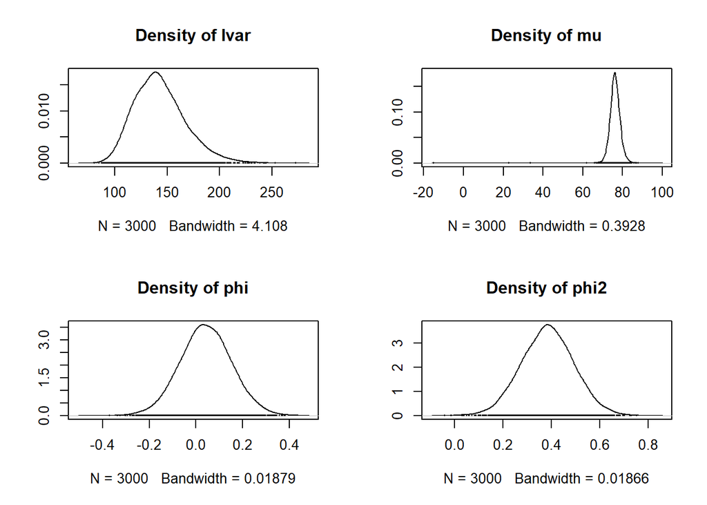

```r
update(jags_AR2, 3000)

samps_AR2=coda.samples(jags_AR2,
                   c('phi','phi2', 'mu','Ivar'),
                   3000)

plot(samps_AR2,trace=FALSE)
```

```r
gelman.diag(samps_AR2)
```

```
## Potential scale reduction factors:
##
##      Point est. Upper C.I.
## Ivar       1.00       1.00
## mu         1.01       1.01
## phi        1.00       1.00
## phi2       1.00       1.00
##
## Multivariate psrf
##
## 1
```

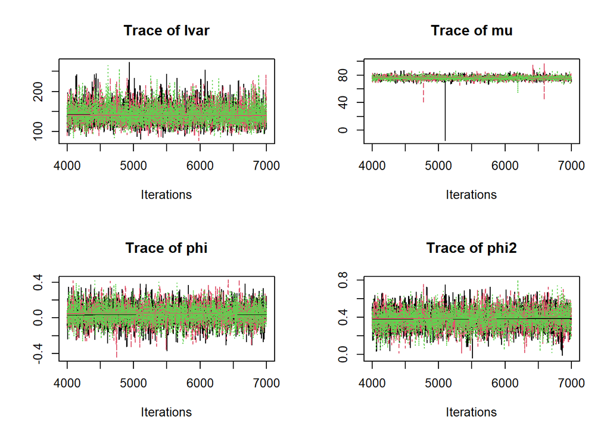

```r
plot(samps_AR2,density=FALSE)
```

```r
summary(samps_AR2)
```

```
##
## Iterations = 4001:7000
## Thinning interval = 1
## Number of chains = 3
## Sample size per chain = 3000
##
## 1. Empirical mean and standard deviation for each variable,
##    plus standard error of the mean:
##
##           Mean      SD Naive SE Time-series SE
## Ivar 143.21839 24.4695 0.257931       0.411193
## mu    76.17757  2.8863 0.030424       0.037698
## phi    0.04236  0.1111 0.001171       0.001759
## phi2   0.38464  0.1088 0.001147       0.001785
##
## 2. Quantiles for each variable:
##
##          2.5%       25%       50%      75%    97.5%
## Ivar 102.7721 125.60392 140.85984 157.6908 198.8255
## mu    71.2401  74.65149  76.15291  77.7189  81.4742
## phi   -0.1747  -0.03072   0.04166   0.1160   0.2613
## phi2   0.1720   0.31156   0.38494   0.4577   0.5981
```

Has the model converged? If so, interpret the resulting parameter estimates. How do the results compare to the arima analysis?

### AR1 model with a covariate

Next, lets add an exogenous covariate to the AR(1) model. We have information on when each women had her period - we will use this to predict each woman’s mood. For this we will load an external data file with the same mood data, and data on each women’s period (0 of not on period, 1 if on period). For the latter variable, for the purpose of this example, we have filled in scores where there were missing observations (because exogenous variables are not allowed to have missing observations in the analysis). An alternative way to deal with this is to make the covariate an endogenous variable (or impute for these observations in another way), but this is beyond the scope of this brief workshop.

Load the data for Mary and Jane, and explore their data with (for instance) a time series plot:

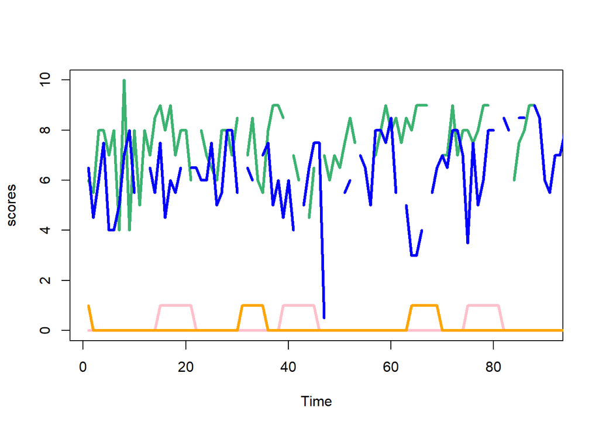

```r
dat_predJane = read.table("Ar1pred_Jane.dat", header=TRUE, na.strings="*")
dat_predMary = read.table("Ar1pred_Mary.dat", header=TRUE, na.strings="*")
mood_J = dat_predJane[,1]
period_J =dat_predJane[,2]
mood_M = dat_predMary[,1]
period_M =dat_predMary[,2]

ts.plot(mood_J/10,col="mediumseagreen",lwd=3, ylab= "scores", ylim=c(0,10))
lines(period_J,col="pink",lwd=3)
lines(period_M,col="orange",lwd=3)
lines(mood_M/10,col="blue",lwd=3)
```

Take a look at the JAGS model code for the AR(1) model with an exogenous predictor ‘AR1predmodel.txt’ (also presented below). What are coefficients b1 and b2? Note: with this model specification we are estimating an intercept directly rather than a mean for mood.

```r
"model{


#####model######
    for (t in 2:nt) ###model for timepoint 2 onwards
    {
        y[t]~dnorm(muy[t],Ipre)  ###Ipre is innovation precision
        muy[t]<- int + phi*y[t-1] + b1*x[t] + b2*x[t-1]

    }

    #####priors###########

    Ipre <- inverse(Ivar) ## innovation precision
    Ivar ~dunif(0,500)   ##innovation variance

    phi~dunif(-1,1) ##autoregression coefficient
    b1~dnorm(0,.001) ##exogenous effect
    b2~dnorm(0,.001) ##exogenous effect (lagged)
    int~dnorm(50,.001) ##intercept



}
"
```

Fit the model to the data for Jane and Mary, check the convergence, and interpret and compare the results.

```r
####Jane#####
jags <- jags.model('AR1predmodel.txt',
                   data = list('nt' = length(mood_J),
                               'y' = as.numeric(mood_J),
                               'x' = as.numeric(period_J)

                   ),
                   n.chains = 3) ###compile and initialize jags AR model
```

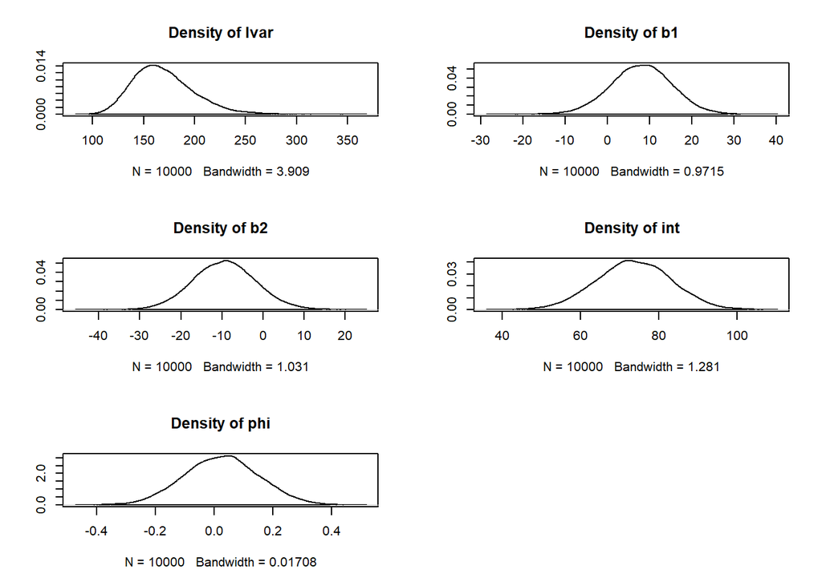

```r
update(jags, 4000) ####burnin

samps=coda.samples(jags,
                   c('phi','b1', 'b2','int', 'Ivar'),
                   10000) ### take samples next to burnin


plot(samps,trace=FALSE) ##plot densities
```

```r
gelman.diag(samps) ###plot gelman rubin stats
```

```
## Potential scale reduction factors:
##
##      Point est. Upper C.I.
## Ivar       1.00       1.00
## b1         1.00       1.01
## b2         1.00       1.00
## int        1.02       1.05
## phi        1.02       1.06
##
## Multivariate psrf
##
## 1.01
```

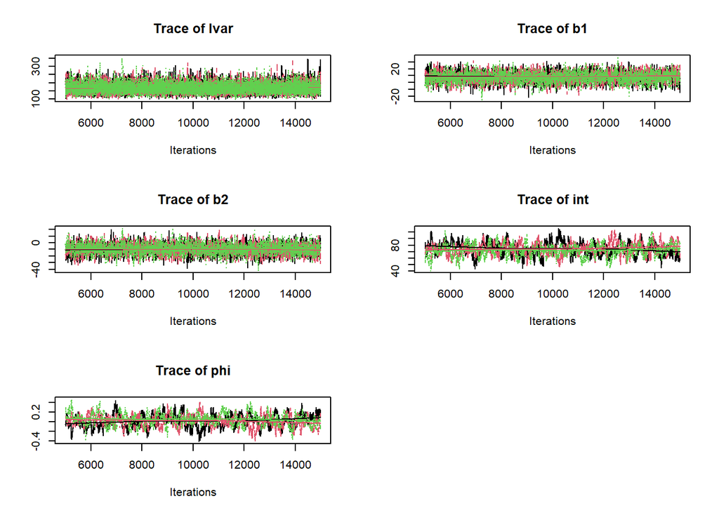

```r
plot(samps,density=FALSE) ##traceplots
```

```r
summary(samps) ##results parameters estimates
```

```
##
## Iterations = 5001:15000
## Thinning interval = 1
## Number of chains = 3
## Sample size per chain = 10000
##
## 1. Empirical mean and standard deviation for each variable,
##    plus standard error of the mean:
##
##           Mean      SD  Naive SE Time-series SE
## Ivar 169.27079 29.7473 0.1717460       0.291086
## b1     7.93957  7.2084 0.0416177       0.150645
## b2    -9.41884  7.6470 0.0441502       0.163104
## int   73.59916  9.4956 0.0548231       0.615636
## phi    0.02572  0.1267 0.0007314       0.008179
##
## 2. Quantiles for each variable:
##
##          2.5%      25%       50%      75%   97.5%
## Ivar 120.8209 148.0177 165.81847 186.8604 235.722
## b1    -6.3708   3.1722   8.03080  12.8253  21.890
## b2   -24.1910 -14.6472  -9.44296  -4.3579   5.841
## int   54.9853  67.2134  73.55553  80.0808  91.977
## phi   -0.2197  -0.0609   0.02647   0.1111   0.274
```

## Basic Bivariate VAR(1) Model

Next we will fit a multivariate, Vector Autoregressive model (of order 1); a VAR(1) model. We will fit the model for two variables, overall mood like before, and nervous tension.

Start by loading the data for both women, and take a look at their time series data. Do the variables seem to sync up over time? What kind of effects would you expect nervous tension and mood to have on each other over time? What about concurrently?

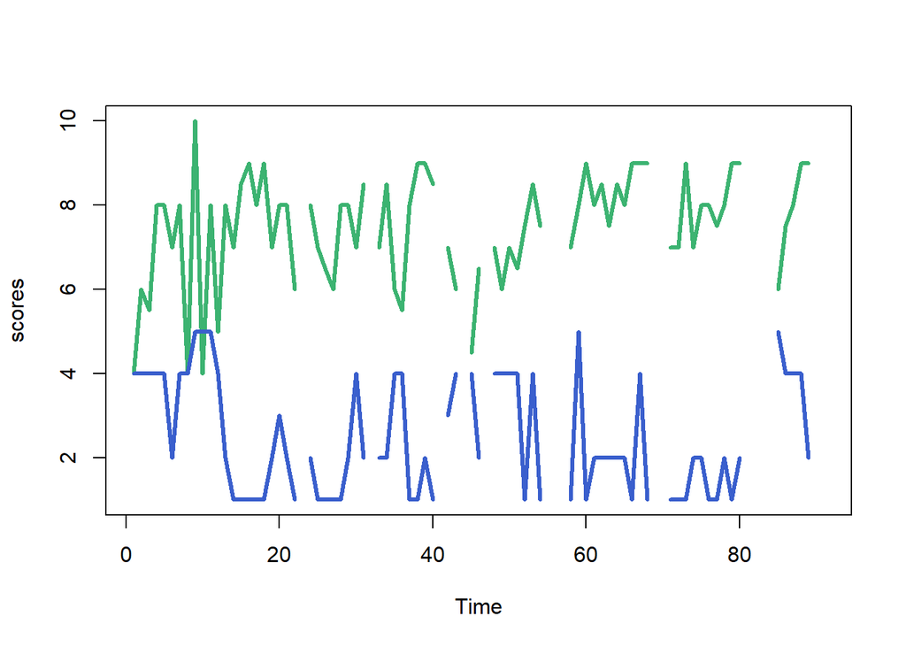

```r
datvar_Jane=data.frame(mydata_Jane$scale,mydata_Jane$nerveuzegespannenheid)
colnames(datvar_Jane) = c("mood", "nervoustension")

datvar_Mary=data.frame(mydata_Mary$scale,mydata_Mary$nerveuzegespannenheid)
colnames(datvar_Mary) = c("mood", "nervoustension")

mood_J = datvar_Jane[,1]
tense_J = datvar_Jane[,2]
ts.plot(mood_J/10,col="mediumseagreen",lwd=3, ylab= "scores", ylim=c(1,10))
lines(tense_J,col="royalblue3",lwd=3)
```

Now, take a look at the JAGS model code for the bivariate VAR(1) model in `Var1model.txt’, also shown below. Do you understand the generalization of the AR(1) model to the multivariate model?

```r
"
model{


#####model######
    for (t in 2:nt) ###model for timepoint 2 onwards
    {
        y[t,1:2]~dmnorm(muy[t,1:2],Ipre[1:2,1:2])  ###Ipre is innovation precision
        muy[t,1]<- mu1 + phi11*z[t-1,1] + phi12*z[t-1,2] ## mu is mean, phi is autoregressive parameters
        muy[t,2]<- mu2 + phi22*z[t-1,2] + phi21*z[t-1,1] ## mu is mean, phi is autoregressive parameters
        z[t,1] <- y[t,1]-mu1
        z[t,2] <- y[t,2]-mu2
    }

####timepoint 1#######

    z[1,1] <- y[1,1]-mu1  ###model for time point one variable 1.
    z[1,2] <- y[1,2]-mu2 ###model for time point one variable 2.


####priors###########

    Ipre <- inverse(Ivar) ## innovation precision matrix
    Ivar[1,1] ~dunif(0,300)   ##innovation variance 1
    Ivar[2,2] ~dunif(0,300)   ##innovation variance 2
    Ivar[1,2] <- Icor*sqrt(Ivar[1,1])*sqrt(Ivar[2,2])  ###innovation covariance
    Ivar[2,1] <- Ivar[1,2] ###innovation covariance
    Icor~dunif(-1,1) ###innovation correlation

    phi11~dnorm(0,.001) ##autoregression coefficient v1
    phi12~dnorm(0,.001) ##cross-lagged coefficient effect of v2 on v1
    phi21~dnorm(0,.001) ##cross-lagged coefficient effect of v1 on v2
    phi22~dnorm(0,.001) ##autoregression coefficient v2

    mu1~dnorm(50,.001) ##mean v1
    mu2~dnorm(3,.001) ##mean v2



}
"
```

Fit the model for Mary and for Jane.

```r
jags <- jags.model('VAR1model.txt',
                   data = list('nt' = nt,
                               'y' = datvar_Jane

                   ),
                   n.chains = 3) ###compile and initialize jags AR model
```

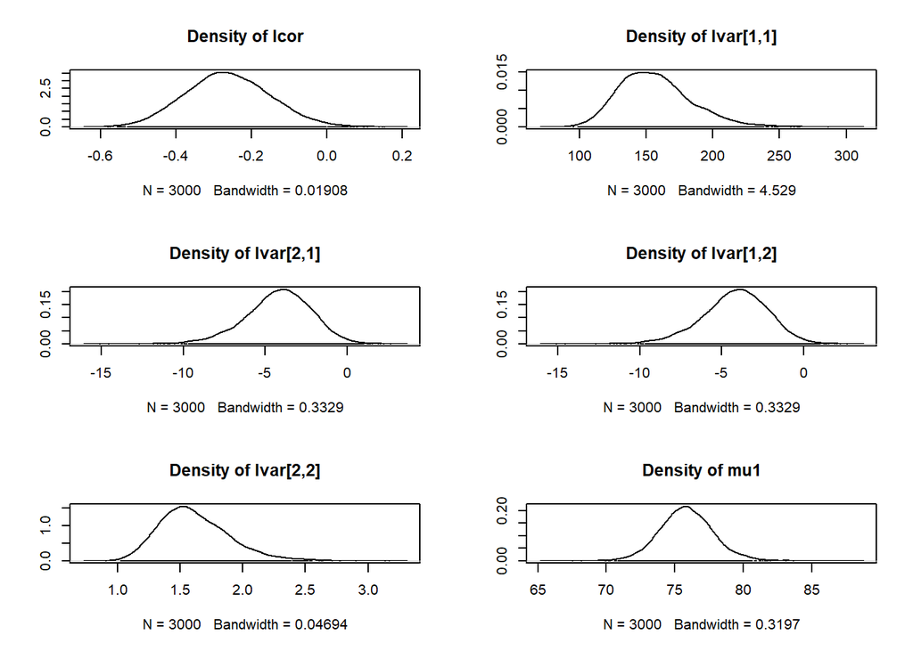

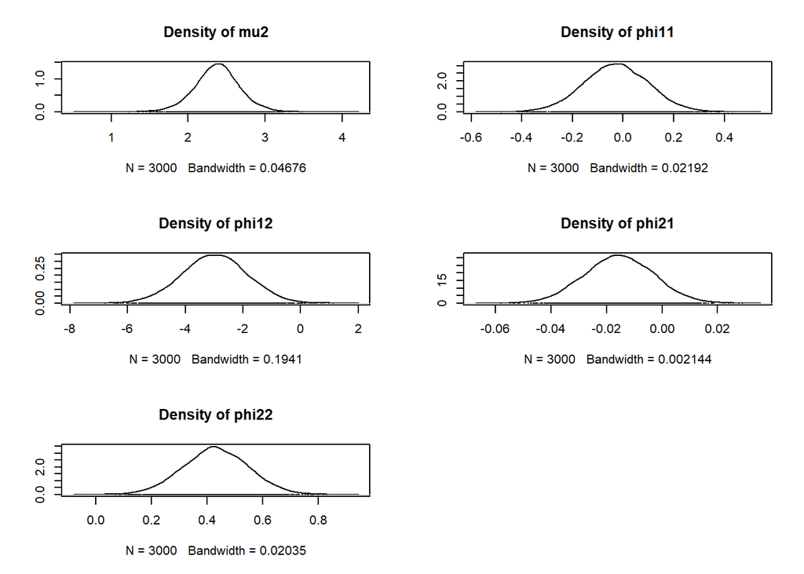

```r
update(jags, 2000) ####burnin

samps=coda.samples(jags,
                   c('phi11','phi22', 'mu1','phi12','phi21', 'mu2', 'Ivar', 'Icor'),
                   3000) ### take samples next to burnin

plot(samps,trace=FALSE) ##plot densities
```

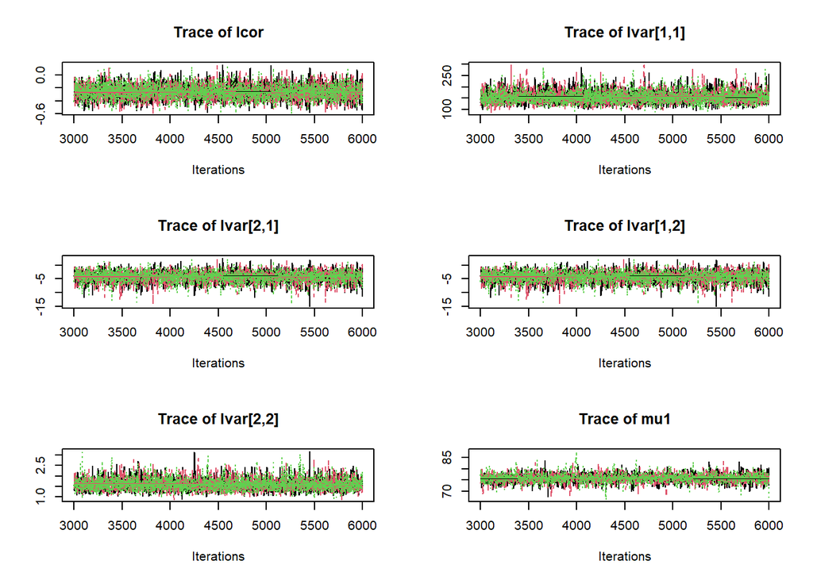

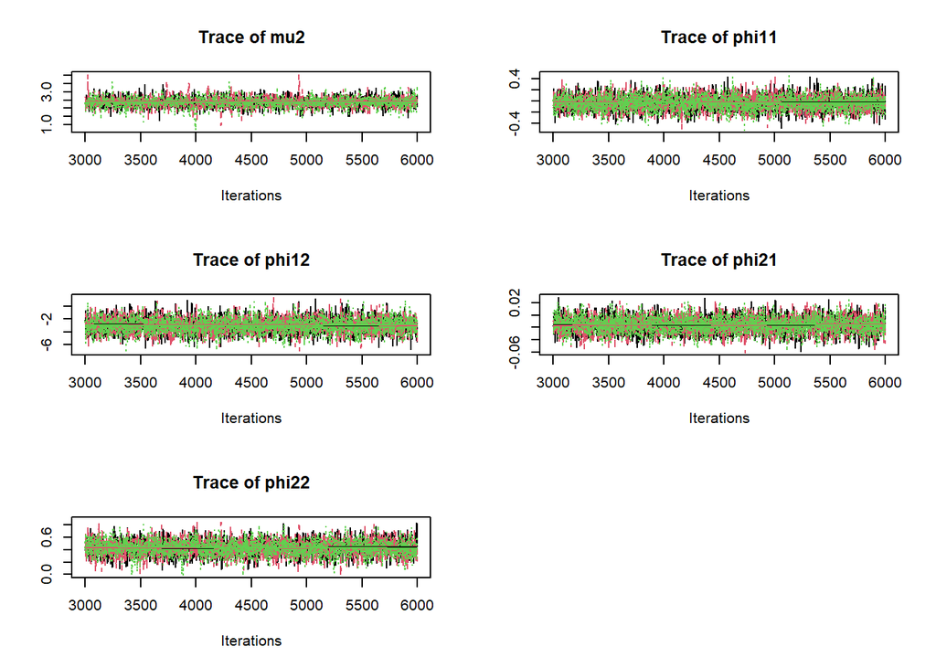

```r
#gelman.diag(samps) ###plot gelman rubin stats

plot(samps,density=FALSE) ##traceplots
```

```r
summary(samps) ##results parameters estimates
```

```
##
## Iterations = 3001:6000
## Thinning interval = 1
## Number of chains = 3
## Sample size per chain = 3000
##
## 1. Empirical mean and standard deviation for each variable,
##    plus standard error of the mean:
##
##                Mean       SD  Naive SE Time-series SE
## Icor       -0.26191  0.11122 0.0011723      0.0019110
## Ivar[1,1] 156.84123 27.36729 0.2884766      0.4834785
## Ivar[2,1]  -4.19803  2.02574 0.0213532      0.0367970
## Ivar[1,2]  -4.19803  2.02574 0.0213532      0.0367970
## Ivar[2,2]   1.61504  0.28254 0.0029782      0.0048966
## mu1        75.81865  1.98577 0.0209318      0.0456678
## mu2         2.37420  0.30131 0.0031761      0.0068510
## phi11      -0.02773  0.12776 0.0013467      0.0021746
## phi12      -2.97787  1.13878 0.0120038      0.0194241
## phi21      -0.01556  0.01249 0.0001317      0.0002029
## phi22       0.43133  0.11921 0.0012565      0.0021095
##
## 2. Quantiles for each variable:
##
##                2.5%       25%       50%        75%      97.5%
## Icor       -0.46972  -0.33860  -0.26519  -0.188232  -0.036507
## Ivar[1,1] 112.35030 137.25410 154.09217 172.628399 217.647304
## Ivar[2,1]  -8.54389  -5.42567  -4.07404  -2.826002  -0.567189
## Ivar[1,2]  -8.54389  -5.42567  -4.07404  -2.826002  -0.567189
## Ivar[2,2]   1.15914   1.41491   1.57979   1.781520   2.265572
## mu1        72.00086  74.55811  75.79146  77.054631  79.916455
## mu2         1.76529   2.19076   2.37622   2.555917   2.972308
## phi11      -0.27750  -0.11380  -0.02807   0.059166   0.224333
## phi12      -5.22154  -3.73816  -2.97900  -2.222010  -0.757345
## phi21      -0.04002  -0.02393  -0.01562  -0.007074   0.008834
## phi22       0.19414   0.35229   0.43023   0.511241   0.663395
```

Evaluate the convergence of the model. Interpret the results. Draw a path model (by hand) based on the results for Jane and for Mary, leaving out paths for which the sign of the effect is unclear based on the 95% credible intervals (see quantiles).

## Bonus 1: AR(1) Model that accounts for measurement error

The previous models did not account for measurement error, but it is possible to account for measurement error in dynamic models, even with only one indicator variable (see e.g., Schuurman, Houtveen & Hamaker, 2015; Schuurman & Hamaker, 2020). The dynamic errors (innovations) and measurement errors can be distinguished because the dynamic errors are carried over through the dynamic process, while the measurement errors are unique to a single time point. This means the model is only identified if the autoregressive effect is not exactly zero. It becomes harder to estimate the closer the autoregressive effect is to zero.

The model AR(1) model with measurement error can be specified in JAGS as follows (see als`MEAR1model.txt’):

```r
"
model{


#####model######
    for (t in 2:nt)  ###model for timepoint 2 onwards
    {
        y[t]~dnorm(muy[t],Epre)  ###Epre is measurement precision
        muy[t]<- mu + ytilde[t]  ##mu is mean
        ytilde[t] ~ dnorm(muytilde[t], Ipre) ### Ipre is innovation precision
        muytilde[t] <- phi*ytilde[t-1]       ##phi is autoregression coefficient

    }

####timepoint 1#######

    ytilde[1] <- y[1]-mu

####priors###########

    Epre <- inverse(Evar) ##Measurement error precision
    Evar ~dunif(0,300)   ## measurement error variance
    Ipre <- inverse(Ivar) ## innovation precision
    Ivar ~dunif(0,300) ##innovation variance

    phi~dunif(-1,1) ##autoregression coefficient
    mu~dnorm(50,.001) ##mean



}
"
```

Fit the model for Jane and Mary.

```r
ins = list(list( phi=.6, Ivar = 30, Evar = 20, mu=50),
           list( phi=.3, Ivar = 60, Evar = 40, mu=70),
           list( phi=-.2, Ivar = 20, Evar = 30, mu = 80))  ###initial values ARWN Jags

nt=length(scale)
jags <- jags.model('MEAR1model.txt',
                   data = list('nt' = length(as.numeric(mydata_Jane$scale)),
                               'y' = as.numeric(mydata_Jane$scale)
                   ),
                   inits=ins,
                   n.chains = 3) ###compile and initialize jags ARWN model
```

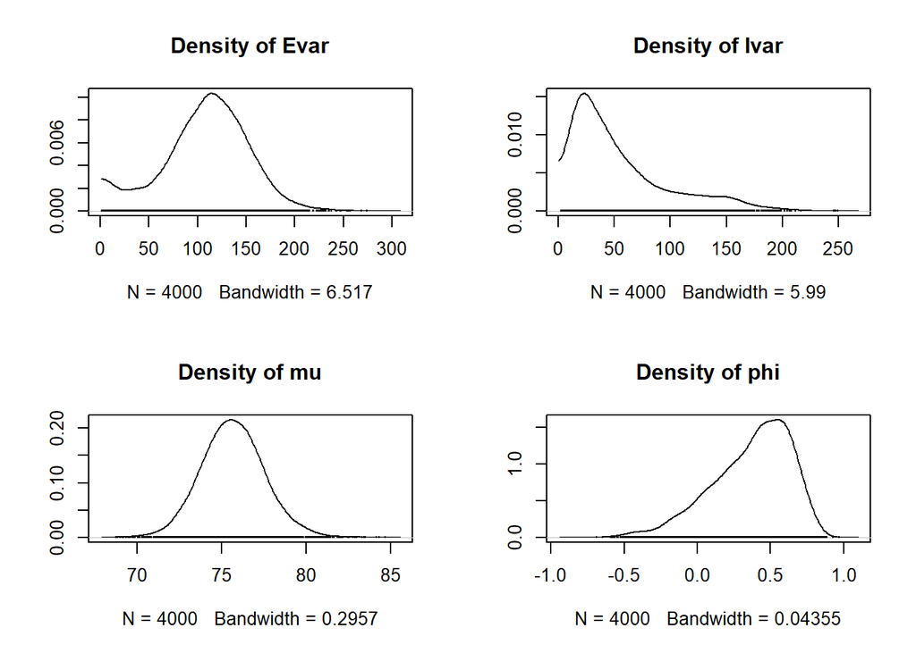

```r
update(jags, 4000) ####burnin

samps=coda.samples(jags,
                   c('phi','mu','Ivar', 'Evar'),
                   4000) ###samples taken next to burnin


plot(samps,trace=FALSE) ###plot densities
```

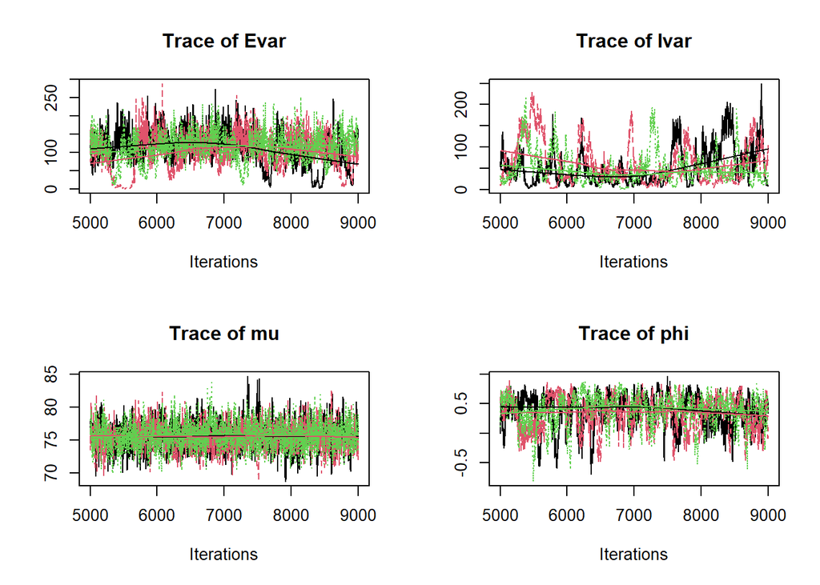

```r
#gelman.plot(samps) ##plot gelman rubin statistics
#gelman.diag(samps) ## table gelman rubin statistics
plot(samps,density=FALSE) ###traceplots
```

```r
summary(samps) ##results parameter estimates
```

```
##
## Iterations = 5001:9000
## Thinning interval = 1
## Number of chains = 3
## Sample size per chain = 4000
##
## 1. Empirical mean and standard deviation for each variable,
##    plus standard error of the mean:
##
##          Mean      SD Naive SE Time-series SE
## Evar 108.6059 44.0642 0.402250        4.38915
## Ivar  54.0477 43.5937 0.397954        5.42150
## mu    75.6714  1.8839 0.017198        0.05359
## phi    0.3684  0.2689 0.002454        0.01767
##
## 2. Quantiles for each variable:
##
##         2.5%     25%     50%      75%    97.5%
## Evar  8.8096 83.7650 112.307 137.6765 189.3922
## Ivar  5.4670 22.3331  40.064  71.8876 164.8881
## mu   72.0877 74.4235  75.642  76.8695  79.5535
## phi  -0.2425  0.2011   0.416   0.5733   0.7671
```

Be sure to check the convergence of the model; the MEAR model can be tricky to estimate, and needs plenty of iterations. If the model has not converged yet, increase the number of burning and samples to keep.

Compare the results for Jane and Mary’s MEAR(1) model to the results for their AR(1) model. What are the main differences?

## Bonus 2: Latent AR(1) model or Dynamic Factor Model

Finally, we will model a latent variable, Postive Affect, with an AR(1) process. Both Jane and Mary provided daily evaluations of 8 positive affect items, namely “attentive”, “strong”, “interested”, “enthusiastic”, “proud”, “determined”, “inspired”, and “exstatic”. We will model a common positive affect factor for these items, and see if there is an autoregressive effect for latent Positive Affect. The model code can be found below, and in `DFAR1model.txt’.

```r
"model{


#####model######
    for (t in 2:nt) ###model for timepoint 2 onwards
    {
        y[t,1]~dnorm(muy[t,1],Ipre[1])  ###Ipre is residual/measurement precision
        muy[t,1]<- mu[1] + l[1]*f[t]
        y[t,2]~dnorm(muy[t,2],Ipre[2])  ###Ipre is residual/measurement precision
        muy[t,2]<- mu[2] + l[2]*f[t]
        y[t,3]~dnorm(muy[t,3],Ipre[3])  ###Ipre is residual/measurement precision
        muy[t,3]<- mu[3] + l[3]*f[t]
        y[t,4]~dnorm(muy[t,4],Ipre[4])  ###Ipre is residual/measurement  precision
        muy[t,4]<- mu[4] + l[4]*f[t]
        y[t,5]~dnorm(muy[t,5],Ipre[5])  ###Ipre is residual/measurement  precision
        muy[t,5]<- mu[5] + l[5]*f[t]
        y[t,6]~dnorm(muy[t,6],Ipre[6])  ###Ipre is residual/measurement  precision
        muy[t,6]<- mu[6] + l[6]*f[t]
        y[t,7]~dnorm(muy[t,7],Ipre[7])  ###Ipre is residual/measurement  precision
        muy[t,7]<- mu[7] + l[7]*f[t]
        y[t,8]~dnorm(muy[t,8],Ipre[8])  ###Ipre is residual/measurement  precision
        muy[t,8]<- mu[8] + l[8]*f[t]

        f[t]~dnorm(muf[t],Fpre)
        muf[t]<- phi*f[t-1]  #Note the factor mean is essentially fixed to zero by not including an intercept, for scaling purposes.


    }


    #####priors###########
    f[1]~dnorm(0,1) #model for time point 1 (should not matter too much what we specify here if we have enough repeated measures)

    Fpre[1] <- inverse(Ivar[1]) ## innovation/dynamic error precision for the latent variable     Fvar[1] ~dunif(0,50)    ## innovation/dynamic error variance for the latent variable
    Ipre[1] <- inverse(Ivar[1])
    Ivar[1] ~dunif(0,50)   ##residual/measurement variance
    Ipre[2] <- inverse(Ivar[2])
    Ivar[2] ~dunif(0,50)   ##residual/measurement variance
    Ipre[3] <- inverse(Ivar[3])
    Ivar[3] ~dunif(0,50)  ###residual/measurement variance
    Ipre[4] <- inverse(Ivar[4])
    Ivar[4] ~dunif(0,50)   ##residual/measurement variance
    Ipre[5] <- inverse(Ivar[5])
    Ivar[5] ~dunif(0,50)   ##residual/measurement variance
    Ipre[6] <- inverse(Ivar[6])
    Ivar[6] ~dunif(0,50)  #residual/measurement variance
    Ipre[7] <- inverse(Ivar[7]) #
    Ivar[7] ~dunif(0,50)   ##residual/measurement variance
    Ipre[8] <- inverse(Ivar[8])
    Ivar[8] ~dunif(0,50)   ##residual/measurement variance

    phi~dunif(-1,1) ##autoregression coefficient
    mu[1]~dnorm(0,.001) ##mean
    mu[2]~dnorm(0,.001) ##mean
    mu[3]~dnorm(0,.001) ##mean
    mu[4]~dnorm(0,.001) ##mean
    mu[5]~dnorm(0,.001) ##mean
    mu[6]~dnorm(0,.001) ##mean
    mu[7]~dnorm(0,.001) ##mean
    mu[8]~dnorm(0,.001) ##mean
    l[1]<-1 #fixed to 1 for scaling purposes.
    l[2]~dnorm(0,.001) ##loading
    l[3]~dnorm(0,.001) ##loading
    l[4]~dnorm(0,.001)  ##loading
    l[5]~dnorm(0,.001) ##loading
    l[6]~dnorm(0,.001) ##loading
    l[7]~dnorm(0,.001) ##loading
    l[8]~dnorm(0,.001) ##loading


}
"
```

Load the data for Jane and Mary, and look at the time series for the different items. Fit the model for Jane and Mary, and draw a path model for both of them based on the results.

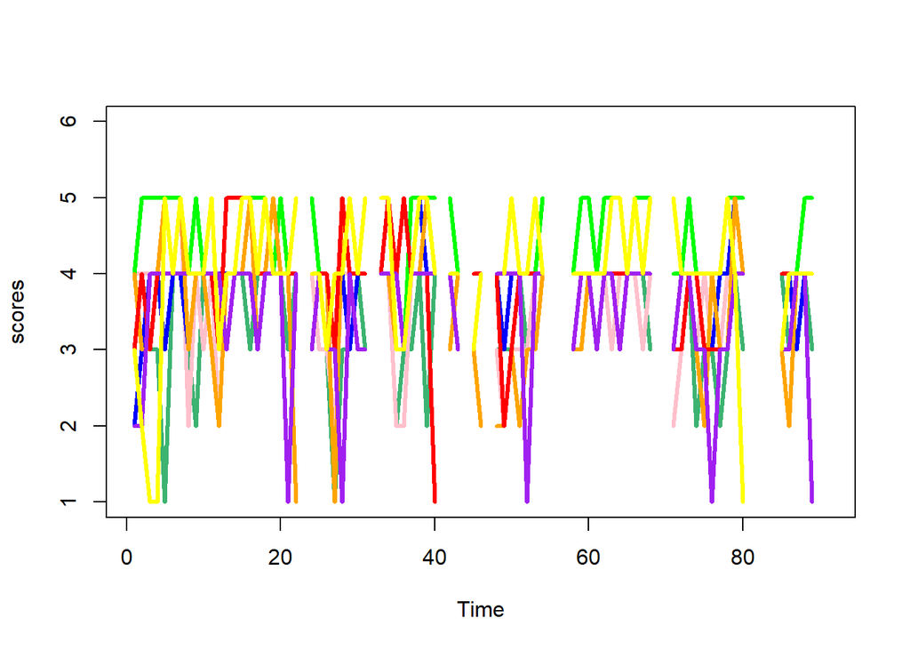

```r
#Prepare the data
datser=data.frame(mydata_Jane$aandachtig, mydata_Jane$sterk,mydata_Jane$geinteresseerd,mydata_Jane$enthousiast, mydata_Jane$trots,mydata_Jane$vastberaden,mydata_Jane$geinspireerd, mydata_Jane$uitgelaten)

datser=as.matrix(datser)

colnames(datser) = c("attentive", "strong", "interested", "enthusiastic", "proud", "determined", "inspired", "exstatic")  #english translations of the items we picked

ts.plot(datser[,1],col="mediumseagreen",lwd=3, ylab= "scores", ylim=c(1,6))
lines(datser[,2],col="pink",lwd=3)
lines(datser[,3],col="blue",lwd=3)
lines(datser[,4],col="green",lwd=3)
lines(datser[,5],col="orange",lwd=3)
lines(datser[,6],col="red",lwd=3)
lines(datser[,7],col="purple",lwd=3)
lines(datser[,8],col="yellow",lwd=3)
```

```r
jags <- jags.model('DFAR1model.txt',
                   data = list('nt' = length(datser[,1]),
                               'y' = datser


                   ),
                   n.chains = 3) ###compile and initialize jags AR model
```

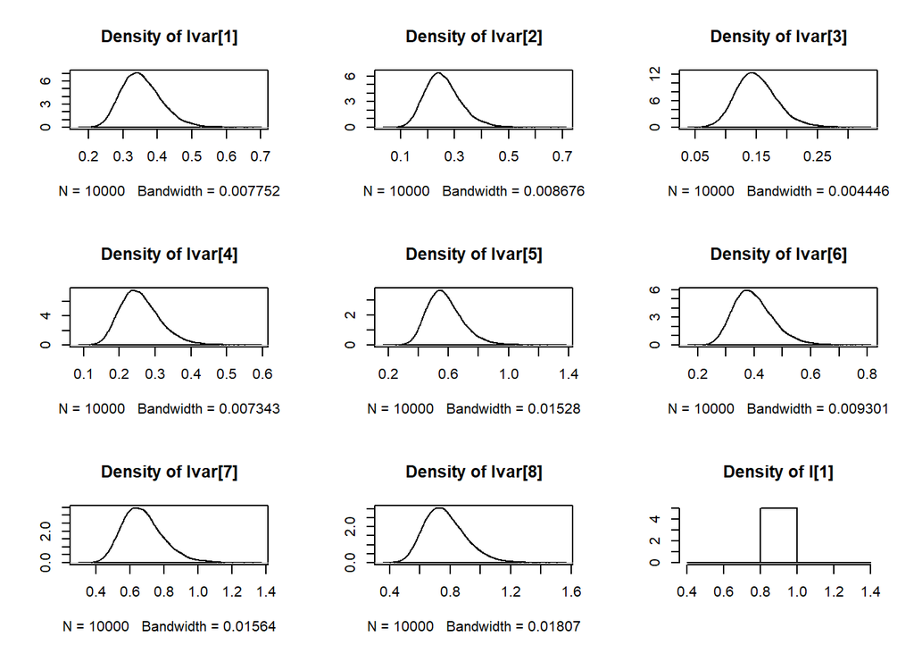

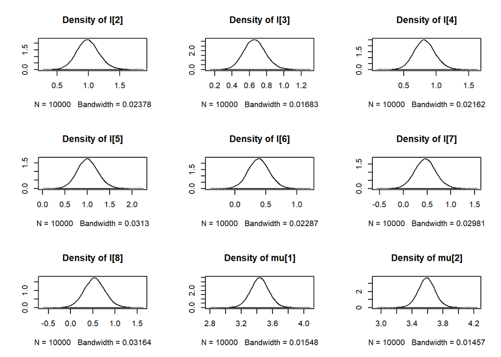

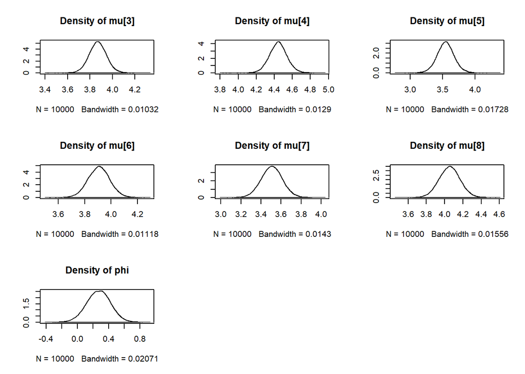

```r
update(jags, 5000) ####burnin

samps=coda.samples(jags,
                   c('phi','l', 'mu','Ivar'),
                   10000) ### take samples next to burnin


plot(samps,trace=FALSE) ##plot densities
```

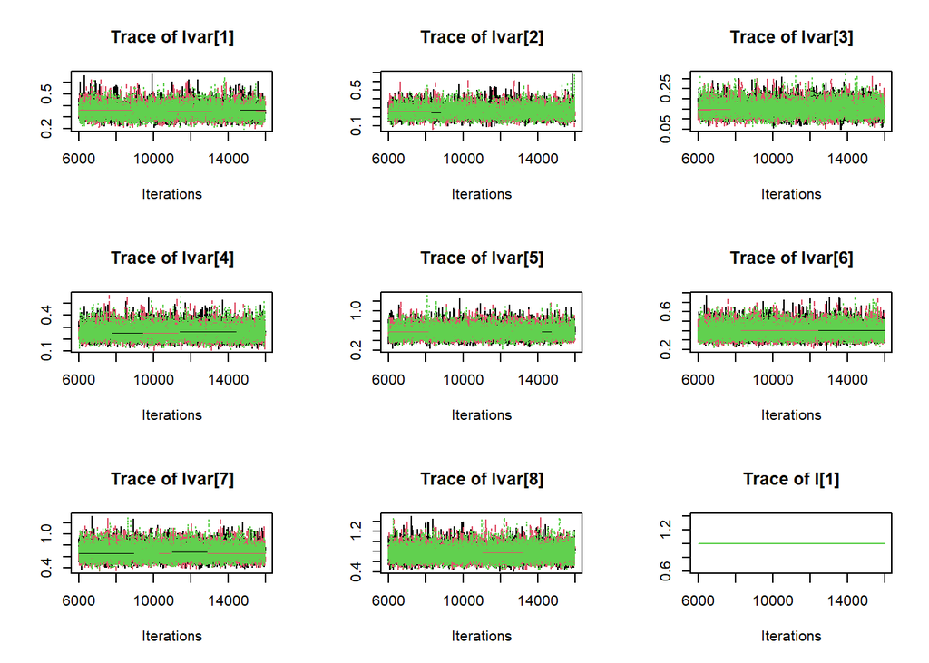

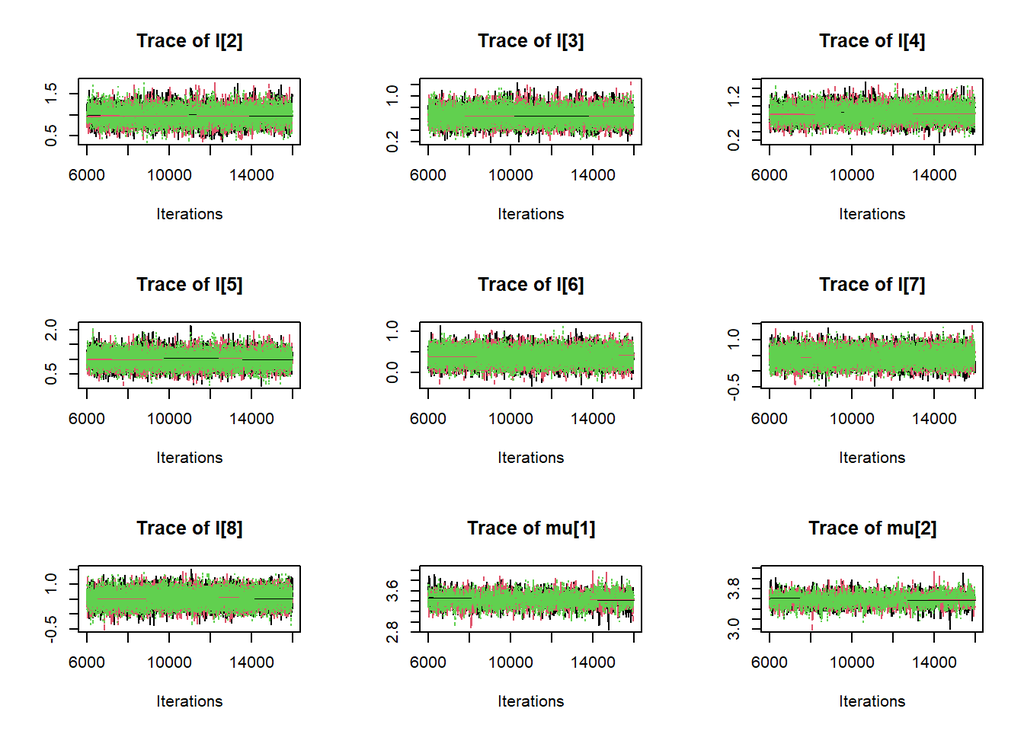

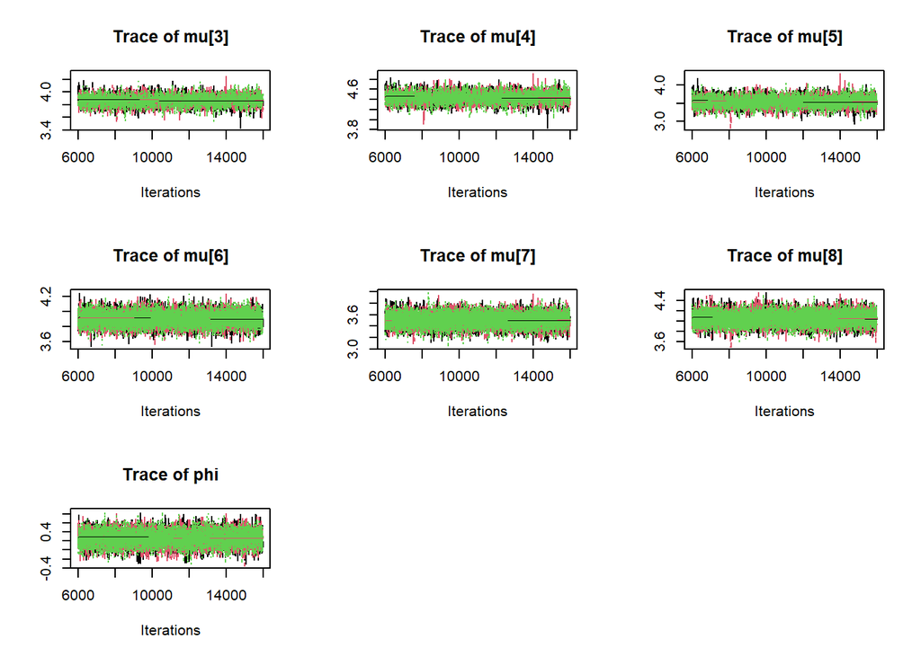

```r
#gelman.plot(samps) ###plot gelman rubin stats
#gelman.diag(samps) ## table gelman rubin statistics

plot(samps,density=FALSE) ##traceplots
```

```r
summary(samps) ##results parameters estimates
```

```
##
## Iterations = 6001:16000
## Thinning interval = 1
## Number of chains = 3
## Sample size per chain = 10000
##
## 1. Empirical mean and standard deviation for each variable,
##    plus standard error of the mean:
##
##           Mean      SD  Naive SE Time-series SE
## Ivar[1] 0.3545 0.05849 0.0003377      0.0008607
## Ivar[2] 0.2573 0.06669 0.0003850      0.0010180
## Ivar[3] 0.1508 0.03398 0.0001962      0.0004541
## Ivar[4] 0.2586 0.05631 0.0003251      0.0006665
## Ivar[5] 0.5770 0.11861 0.0006848      0.0013554
## Ivar[6] 0.3976 0.07055 0.0004073      0.0005893
## Ivar[7] 0.6753 0.11929 0.0006887      0.0009806
## Ivar[8] 0.7674 0.13665 0.0007889      0.0011376
## l[1]    1.0000 0.00000 0.0000000      0.0000000
## l[2]    0.9899 0.18024 0.0010406      0.0026918
## l[3]    0.6625 0.12636 0.0007295      0.0016018
## l[4]    0.8220 0.16205 0.0009356      0.0020183
## l[5]    1.0108 0.23426 0.0013525      0.0027934
## l[6]    0.3883 0.17072 0.0009857      0.0014217
## l[7]    0.4605 0.22401 0.0012933      0.0019322
## l[8]    0.5391 0.23813 0.0013748      0.0019631
## mu[1]   3.4369 0.11922 0.0006883      0.0029484
## mu[2]   3.5890 0.11294 0.0006521      0.0028998
## mu[3]   3.8684 0.07788 0.0004496      0.0018804
## mu[4]   4.4425 0.09972 0.0005757      0.0024530
## mu[5]   3.5454 0.13370 0.0007719      0.0030610
## mu[6]   3.9070 0.08324 0.0004806      0.0011515
## mu[7]   3.5072 0.10683 0.0006168      0.0014249
## mu[8]   4.0534 0.11602 0.0006699      0.0016393
## phi     0.2691 0.15359 0.0008867      0.0018537
##
## 2. Quantiles for each variable:
##
##             2.5%    25%    50%    75%  97.5%
## Ivar[1]  0.25724 0.3130 0.3488 0.3900 0.4848
```

[output cut: 9 more lines]

```
## l[3]     0.42545 0.5767 0.6594 0.7440 0.9211
## l[4]     0.51377 0.7120 0.8177 0.9268 1.1525
## l[5]     0.55950 0.8523 1.0054 1.1633 1.4890
## l[6]     0.05248 0.2732 0.3870 0.5004 0.7276
## l[7]     0.02504 0.3101 0.4585 0.6063 0.9128
## l[8]     0.07523 0.3803 0.5372 0.6947 1.0179
## mu[1]    3.20192 3.3603 3.4368 3.5141 3.6714
## mu[2]    3.36644 3.5170 3.5893 3.6618 3.8131
## mu[3]    3.71453 3.8171 3.8682 3.9197 4.0223
## mu[4]    4.24834 4.3778 4.4431 4.5060 4.6398
## mu[5]    3.28021 3.4592 3.5455 3.6309 3.8134
## mu[6]    3.74433 3.8514 3.9074 3.9625 4.0712
## mu[7]    3.29654 3.4363 3.5076 3.5784 3.7168
## mu[8]    3.82636 3.9756 4.0536 4.1302 4.2811
## phi     -0.03707 0.1665 0.2716 0.3731 0.5652
```

Compare the models for Mary and Jane. Would you guess based on these results - based on just eyeballing the parameter estimates - that Positive Affect is measurement invariant for Jane and Mary (that the latent variable represent the same thing for Jane and Mary)? If not, how do they seem to differ?

## End of n=1 practical.

This is the end of part 1 of our exercises for today. I hope you’ve been able to get an impression of n=1 discrete time modeling of intensive longitudinal data, and the individual differences in dynamic processes. Of course, we treated time as discrete in this practical. In the next part of the workshop, we will look at what happens when we treat time as continuous.

Further note that all the analyses today are n=1, but you can find a multilevel practical on my website, www.nkschuurman.com, if you are interested (either in Mplus or R).